# Machine Learning

## Allgemeines

### Was ist ML?

Wissenschaft von Algorithmen, die ohne menschliches Eingreifen (Ableitung von Regeln, Erstellung von Modellen) den Sinn von Daten erkennen.

### Arten von ML

#### Überwacht

**Überwachtes Lernen**

- gekennzeichnete Daten
- direktes Feedback
- Methoden
  - Klassifizierung
  - Regression (Voraussage stetiger Werte)

#### Verstärkend

**Verstärkendes Lernen**

- Agent, der seine Leistung durch Interaktion mit seiner Umgebung verbessert
- Belohnungssystem

#### Unüberwacht

**Unüberwachtes Lernen**

- keine Kennzeichnung
- verborgene Strukturen finden
- Methoden
  - Clustering - *unüberwachte Klassifizierung*
  - Datenkomprimierung

### Ablauf

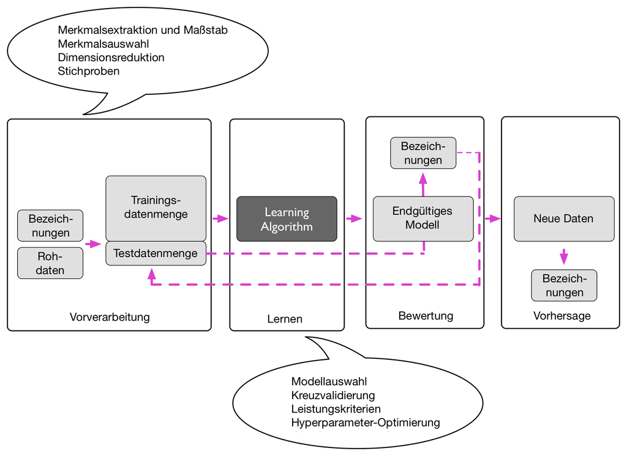

## Datenvorbereitung

Entscheidende Faktoren für Datensätze sind Umfang, Auswahl und Qualität

## Datenkomprimierung

Mithilfe der Datenkomprimierung sollen Merkmale zusammengefasst werden, indem diese in einen neuen Merkmalsraum transformiert werden.

### PCA

**Principal Component Analysis**

Mithilfe des PCA wird ein Untermerkmalsraum mit maximaler Varianz entlang der orthogonalen Merkmalsachse konstruiert. Es werden Kovarianzmatrizen konstruiert, und durch Zerlegung in Eigenwerte und Vektoren die Vektoren mit den größten Eigenwerten selektiert. Daraus wird eine Projektionsmatrix erzeugt, mit der ein neuer Merkmalsunterraum betrachtet werden kann (weniger Merkmale als vorher).

- unüberwachtes Verfahren
- erhöht Effizienz der Berechnung
- reduziert Rauschen

### LDA

**Linear Discriminant Analysis**

LDA versucht einen Merkmalsunterraum zu finden, der die Trennbarkeit der Klassen optimiert (maximale Separierbarkeit). Dafür werden Mittelwertvektoren und zwei resultierende Streumatrizen berechnet (innerhalb $S_w$ und zwischen $S_B$ den Klassen). Anschließend erneute Eigenwertzerlegung mit $S_w^{-1}S_B$.

- überwachtes Verfahren (Klassenzugehörigkeit)
- erhöht Effizienz der Berechnung

### Kernel PCA

**Kernel PCA**

Ziel des Kernel PCAs ist es, nicht-linear trennbare Daten in neue, linear trennbare Daten umzuwandeln. Berechnung einer zentrierten Kernel-Matrix für jedes Element der Datenmenge um anschließend die Eigenwerte und Eigenvektoren bestimmen zu können. Die Konstruktion eine Projektionsmatrix ist nicht notwendig.

1. Transformation der Aktivierungsfunktion $\phi$ in höherdimensionierten Raum
2. finden einer linearen Hyperebene
3. Rücktransformation

## Klassifierzungs-Algorithmen

### Perzeptron

**Perzeptron**

#### Mathematische Grundlagen

- binäre Klassifizierung (positiv (+1) und negativ (-1))
- Gewichtungsvektor $w$ und Eingabevektor $x$
- Aktivierungsfunktion $\phi(z)$ mit $z = w_0 x_0 + w_1 x_1 + w_2 x_2 + ... + w_i x_i$
  - $w_0 = - \Theta$
  - $x_0 = 1$

$$\phi(z) = \begin{cases}
1 & \text{wenn } z \ge 0 \\[4mm]
-1 & \text{andernfalls}
\end{cases}$$

Ermittlung von $w$:

- Aktualisierung der Gewichte: $w_j := w_j + \Delta w_j$ (bei jedem Objekt)
  - mit $\Delta w_j = \eta ( y^{i} - \hat{y}^{i}) x_j^{i}$
  - Die Aktualisierung der Gewichte erfolgt bei jedem Objekt
- $\eta$: Lernrate (typischerweise zwischen 0 und 1)
- $y^{i}$ : tatsächliche Klassenbezeichnung
- $\hat{y}^{i}$ : vorhergesagte Klassenbezeichnung

#### Parameter

- `eta0`: Lernrate (Größe der Schritte)
- `max_iter`: Anzahl der Epochen

#### Ablauf / Prozess

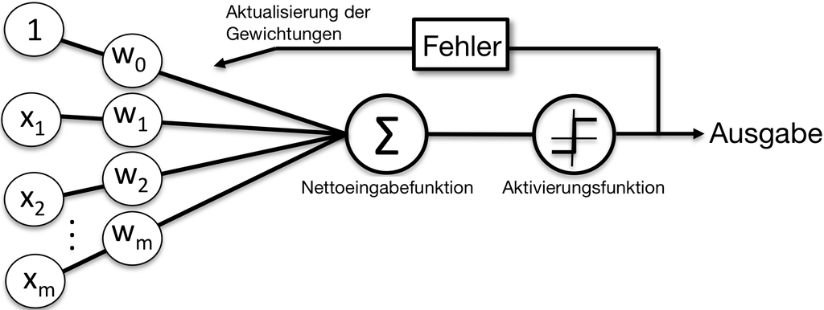

### Adaline

**Adaline (ADAptive LInear NEuron classifier)**

Lineare Aktivierungsfunktion anstelle von einer Sprungfunktion. Gradientenabstiegsverfahren einer Straffunktion $J$

#### Mathematische Grundlagen

Straffunktion als Summe der quadratischen Abweichungen:

$$J(w) = \frac{1}{2} \sum_{i} \left( y^{i} -\phi(w^T x^{i}) \right)^2$$

Die Änderung $\Delta w = -\eta \nabla J(w)$ ergibt sich aus dem Gradienten, also der partiellen Ableitung von $J(w)$:
$$\frac{\partial J}{\partial w_j} = ... = - \sum_{i} \left( y^{i} -\phi(z^{i}) \right) x_j^{i}$$

- Aktualisierung der Gewichte $w := w + \Delta w$
  - mit $\Delta w_j = - \eta \frac{\partial J}{\partial w_j} = \eta \sum_{i} \left( y^{i} -\phi(z^{i}) \right) x_j^{i}$
  - Die Aktualisierung erfolgt per Stapelverarbeitung nach Berechnung des Gradienten nur einmal

#### Parameter

- `eta0`: Lernrate (Größe der Schritte)
- `max_iter`: Anzahl der Epochen

### Logistische Regression

**Logistische Regression**

Ähnlich zu Adaline, anstelle einer linearen Aktivierungsfunktion wird eine Sigmoid-Funktion verwendet. Es kann eine Aussage darüber getroffen werden, wie wahrscheinlich es ist, dass ein Merkmal $x$ zu einer Klasse $y$ gehört. Stochastisches Gradientenabstiegsverfahren ist möglich.

#### Mathematische Grundlagen

Sigmoid-Funktion
$$\phi(z) = \phi (w^T x) = \frac{1}{1 + e^{-z}} = \frac{1}{1 + e^{- w^T x}}$$
als Aktivierungsfunktion $\phi(z)$.

Neue Straffunktion als Likelihood $L$ bzw. besser: Log-Likelihood.
$$J(w) = -l(w) = log(L(w))$$
$$log(L(w)) = \sum_{i=0}^{n} y^{i} \log (\phi(z^{i}) + (1 - y^{i}) \log (1 - \phi(z^{i})$$

Die Änderung $\Delta w = -\eta \nabla J(w)$ erfolgt erneut mit der partiellen Ableitung der Straffunktion $J$.

- Aktualisierung der Gewichte $w := w + \Delta w$
  - mit $\Delta w = \eta \sum_{i=1}^n \left( y^{} - \phi(z^{i})\right) x^{i}$
  - falsche Vorhersagen werden härter bestraft

#### Parameter

- `max_iter`: Anzahl der Epochen
- `solver`: z.B. `'lbfgs'`
- `penalty`: Regularisierung z.B. `l2`

### SVM

**Support Vector Machine**

Methode, um den Abstand (*margin*) zwischen Klassengrenzen zu maximieren.

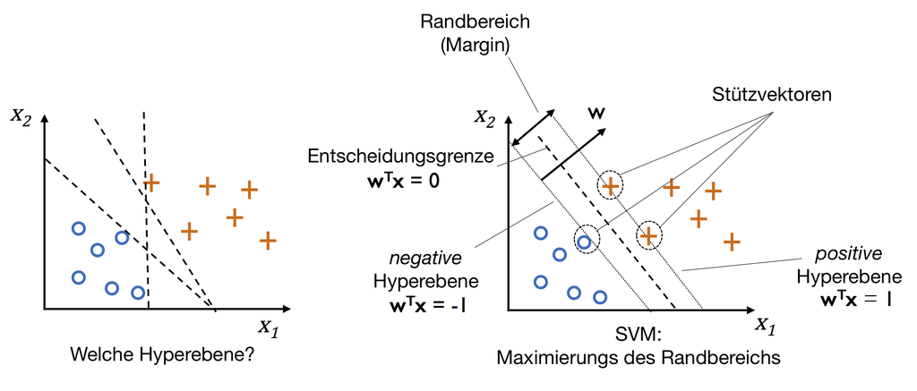

Auch nicht-lineare Entscheidungsgrenzen sind realisierbar.

#### Mathematische Grundlagen

Einteilung in

- Entscheidungsgrenze
- positive Hyperebene
- negative Hyperebene

Nicht-linear trennbare Entscheidungsgrenzen

1. Transformation der Aktivierungsfunktion $\phi$ in höherdimensionierten Raum
2. finden einer linearen Hyperebene
3. Rücktransformation
- Alternativ mithilfe eines Kernel-Tricks (**R**adial **B**ase **F**unction-Kernel)

#### Parameter

- `max_iter`: Anzahl der Epochen
- `C`: Regularisierung (niedrig = starke Regularisierung)
- `kernel`: z.B. `'rbf'` für nicht-lineare Entscheidungsgrenzen
- `gamma`: Als Parameter des veränderten Kernels

### Entscheidungsbäume

**Entscheidunsbäume**

Durch Treffen von Entscheidungen werden Grenzen gezogen (keine Funktion / Linie sondern Stufen). Reelle Zahlen werden zu Entscheidungsfragen umgewandelt.

- Aufteilung der Daten, sodass der größte Informationsgewinn entsteht
- Wiederholen der Aufteilungsprozedur pro Knoten bis zu einem Blattknoten
- Tiefe des Baumes sollte begrenzt sein (Extremfall: jedes Trainingselement hat eigenen Blattknoten)

#### Mathematische Grundlagen

Ziel ist es, den Informationsgewinn $IG$ zu berechnen.

- Setzt sich aus den Daten des Elternknotens und des linken und rechten Kindes zusammen
- *Impurity*-Funktionen zur Auswahl
  - Entropie $I_H$ (mittlerer Informationsgehalt einer Nachricht)
  - Gini-Koeffizient $I_G$ (Reinheit, Minimierung der Wahrscheinlichkeit einer Fehlklassifizierung)
  - Klassifizierungsfehler $I_E$ (Stutzen eines Entscheidungsbaumes, Pruning)

#### Parameter

- `criterion`: *Impurity*-Funktion (Entropie, Gini, Klassifizierungsfehler)
- `max_depth`: Tiefe eines Entscheidungsbaums.

### Random Forest

**Random Forest**

Ensemble von Entscheidungsbäumen. Nutzen mehrerer Entscheidungsbäume mit (jeweils) großer Varianz. Führt zu einem stabileren Modell, dass weniger anfällig für Überanpassung ist.

#### Ablauf

1. Wähle eine zufällige Stichprobe der Größe $n$ aus den Trainingsdaten aus
2. Konstruiere einen Entscheidungsbaum
   1. Wähle zufällig $d$ Merkmale aus
   2. Teilen sie den Knoten auf (anhand der Zielfunktion (*impurity*))
3. Wiederhole 1 und 2 $k$ mal
4. Fasse die Vorhersagen der einzelnen Bäume durch Mehrheitsentscheidung zusammen

#### Paramter

- `criterion`: *Impurity*-Funktion
- `n_estimator`: $k$: Anzahl der Entscheidungsbäume (z.B. Größe der Trainingsdaten)

### kNN

**$k$-Nearest Neighbours**

Zuweisung der Klassenbezeichnung durch Mehrheitsentscheidung anhand eines definierten Abstandsmaßes. Eine Standardisierung ist in jedem Fall notwendig

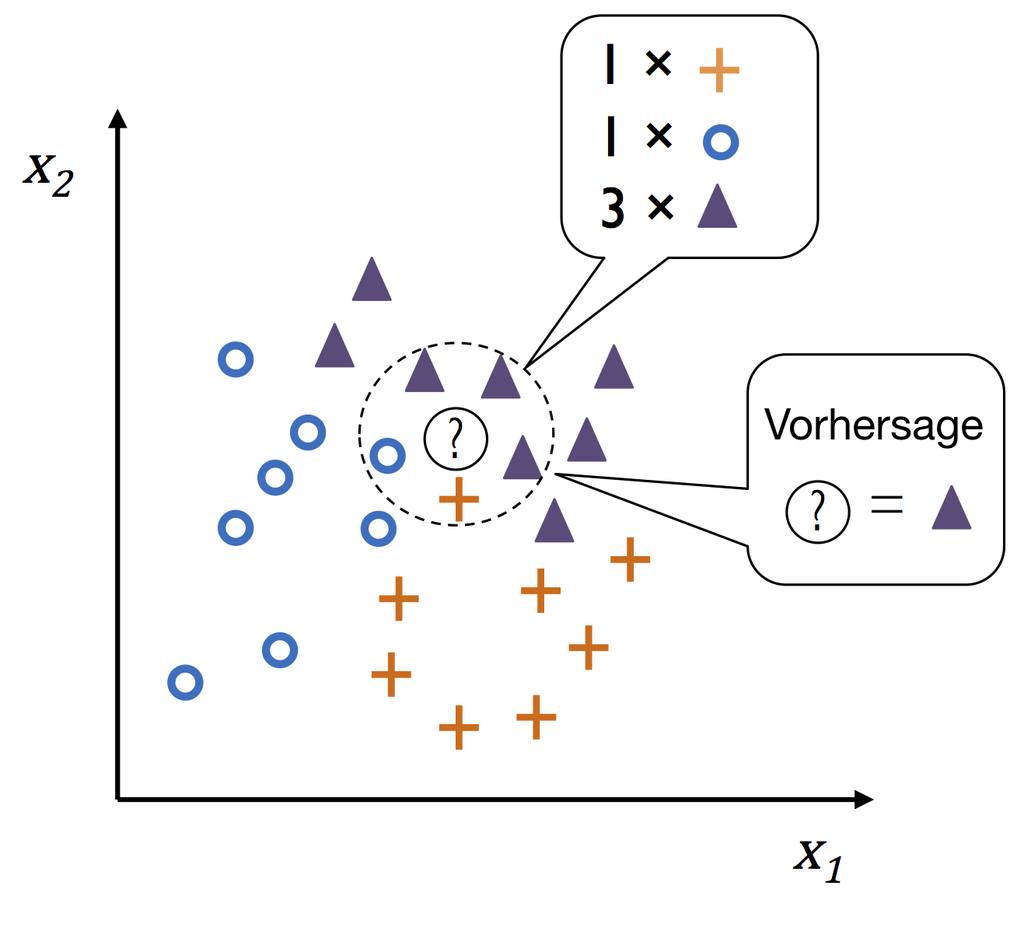

#### Parameter

- `metric`: Metrik z.B. `'minkowski'`
- `p`: `p=1` - Euklid-Abstand, `p=2` - Manhatten-Metrik

### Optimierungen

**Optimierungen** für Klassifzierungs-Algorithmen

#### Standardisierung

**Merkmal-Standardisierung**

Verschieben der Merkmale auf den Mittelwert 0 durch eine Skalierung der Merkmale mittels $\mu$ und $\sigma$, sodass die Standardabweichung 1 ist.
$$x_j^{\prime} = \frac{x_j - \mu_j}{\sigma_j}$$
Auch mithilfe eines `StandardScalers` möglich. Dabei gibt es `transform` und `inverse_transform` um die ursprünglichen Werte zu erhalten.

#### Stoch. Gr.Desc.

**Stochastisches-Gradientenabstiegsverfahren**

Gewichtung inkrementell für jedes Objekt aktualisieren.

- konvergiert schneller
- nur Näherung des normalen Gradientenabstiegsverfahrens
- höheres statistisches Rauschen
- Daten müssen nicht vorweg vorliegen, können inkrementell hinzugefügt werden

#### Überanpassung

**Überanpassung / Unteranpassung**

Überanpassung / Unteranpassung verfälscht die Vorhersage eines Modells und soll vermieden werden.

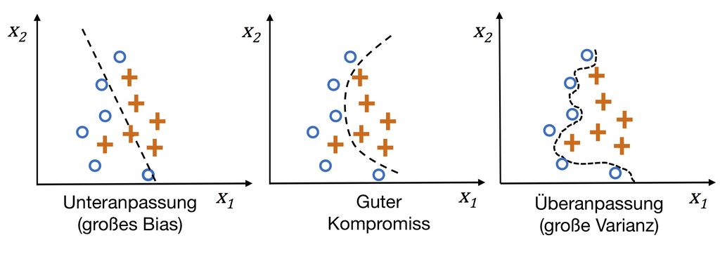

#### Regularisierung

**Regularisierung**

Verhinderung von Überanpassung, indem extreme Parameter (Gewichte) durch einen zusätzlichen Bias bestraft werden. Besonders relevant für `LogisticRegression` und `Support-Vector-Machines`.

Einführung eines Regularisierungsparamters $\lambda$ bzw.
$$C = \frac{1}{\lambda}.$$

- kleines $C$: starke Regularisierung
- großes $C$: starke Anpassung

Beispiel für SVM:

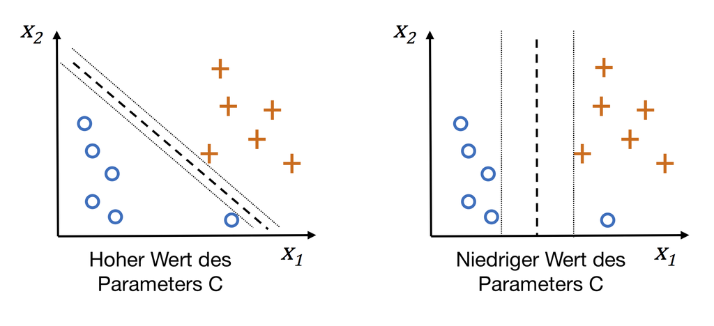

### Modellbewertung

**Modellbewertung** zum Validieren des Modells und zum Finden des *besten* Lernmodells.

#### Pipelines

Optimierung von Arbeitsabläufen durch *Pipelines*

- Aufruf von `fit`
  1. Scaler wird ausgeführt + Übergabe
  2. PCA wird ausgeführt + Übergabe
  3. Schätzer wird ausgeführt
- Aufruf von `predict`
  1. Scaler wird ausgeführt + Übergabe
  2. PCA wird ausgeführt (mit Daten aus `fit`) + Übergabe
  3. Schätzer wird ausgeführt + Vorsage berechnet

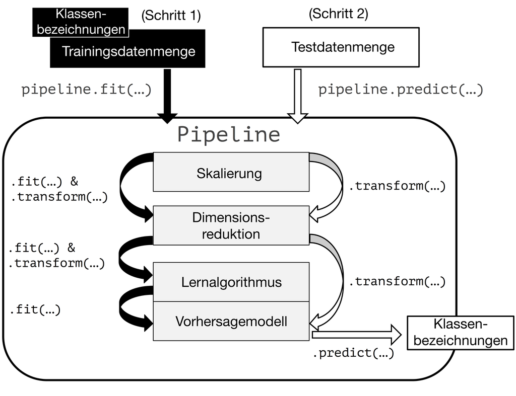

#### Kreuzvalidierung

Kreuzvalidierung um Unter- und Überanpassung zu vermeiden

- $k$-fache Kreuzvalidierung in äußerer Schleife
  1. Aufteilung in Trainings, Testdaten zum Trainieren
  2. Wiederholen bei Neuaufteilung der Datensätze (jede Teilmenge einmal Trainings- bzw. Testdaten)
  3. Berechnung des Durchschnitts der Leistungseinschätzung
- $j$-fache Schleife zur Auswahl des Modells (Überprüfung mit Validierungsdaten)

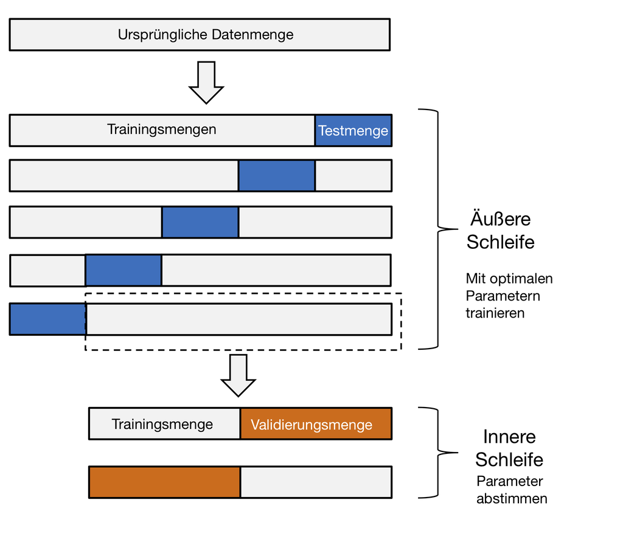

#### Rastersuche

Feinabstimmung von Hyperparametern durch Rastersuche (*Grid Search*)

- Bewertung für verschiedene Parameterkombinationen

Parameter:

- `estimator`: Pipeline
- `param_grid`: Dictionary für Hyperparameter-Kombinationen
- `cv`: Kreuzvalidierung

#### Wahrheitsmatrix

Bewertung des Modells anhand einer Wahrheitsmatrix (Konfusionsmatrix)

- Bestimmung von *true negatives* und *false positives*
- Korrektklassifizierungsrate:
  $$\frac{\text{Richtige Vorhersagen}}{\text{Alle}}$$
- Fehlerquote:
  $$\frac{\text{Falsche Vorhersagen}}{\text{Alle}}$$
- Genauigkeit:
  $$\frac{\text{TP}}{\text{TP + FP}}$$
- Trefferqoute:
  $$\frac{\text{TP}}{\text{TP + FN}}$$
- F1-Maß:
  $$F1 = \frac{2 * GEN * TQ}{GEN + TQ}$$

#### ROC-Diagramme

ROC Diagramme (*Receiver-Operating-Characteristic*)

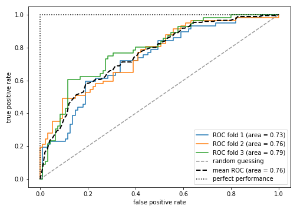

#### Unausgewogene Klassenverteilung

Unausgewogene Klassenverteilung

- Härtere Bestrafung bei falschen Vorhersagen der selteneren Klassen
- Up- oder Down Sampling um den Anteil auszugleichen

## Regressions-Algorithmen

Teil des überwachten Lernens zur Vorhersage eines numerischen, stetigen Wertes anstelle einer Klassenzugehörigkeit.

### Lineare Regression

**Lineare Regression**

Suche nach einer Geraden (*Regressionsgrade*), die am Besten zu der Punktwolke passt.

Korrelationsmatrix

- neu skalierte Version der Kovarianz-Matrix (eng verbunden mit PCA, bei standardisierten Werten gleich)
- trifft eine Aussage darüber, ob eine Korrelation vorliegt (nicht nur linear)

Berechnung der Geraden mithilfe der Methode der kleinsten quadratischen Abstände

$$J(w) = \frac{1}{2} \sum_{i=1}^m \left (y^{(i)} - \hat{y}^{(i)} \right)^2$$

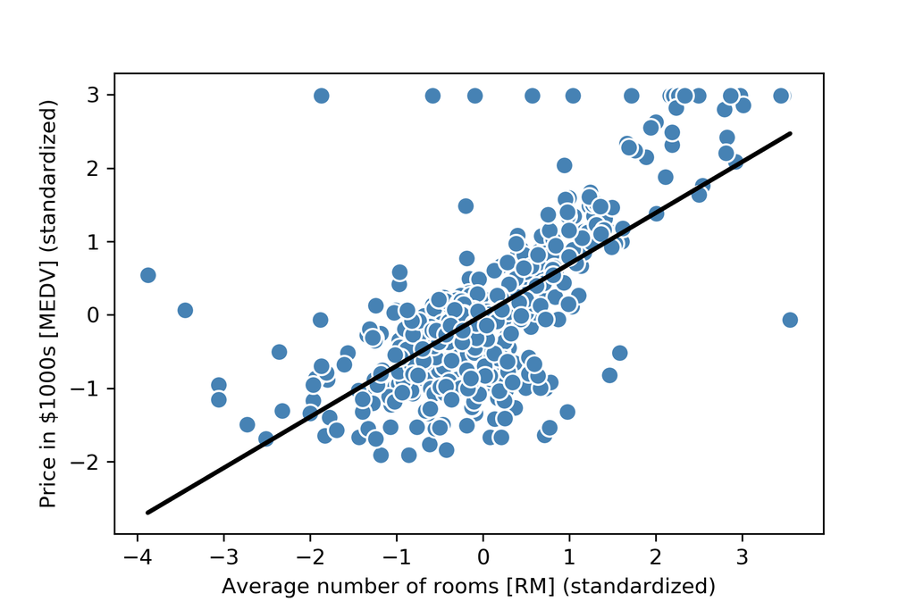

### Polynomale Regression

**Polynomale Regression**

Bilden von Polynomen des Grades $d$.
$$y = w_0 + w_1 x_1 \rightarrow y = w_0 + w_1 x + w_2 x^2 + \cdots + w_d x^d$$

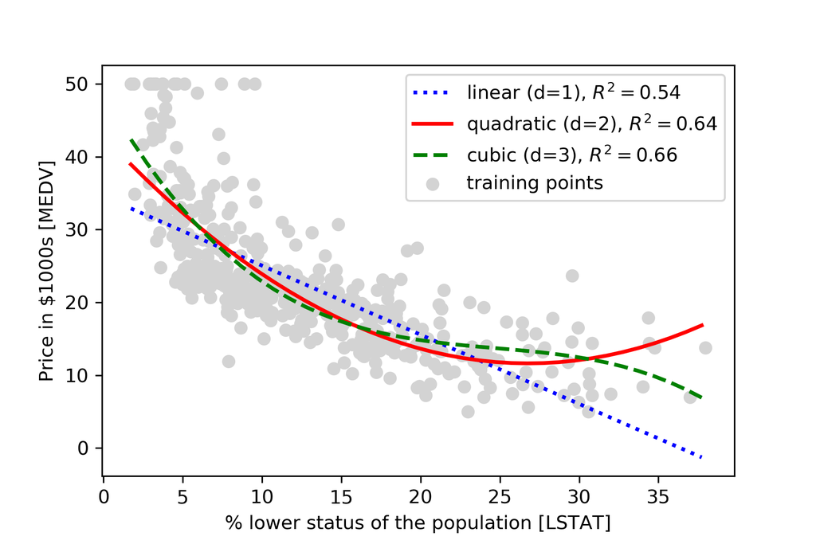

### Enscheidungsbäume / Random-Forest

**Entscheidungsbäume / Random-Forest**

Mithilfe von Entscheidungsbäumen oder des Random-Forest über die Maximierung des Informationsgewinn $IG$ oder die Minimierung der Unreinheit stetige Vorhersagen treffen.

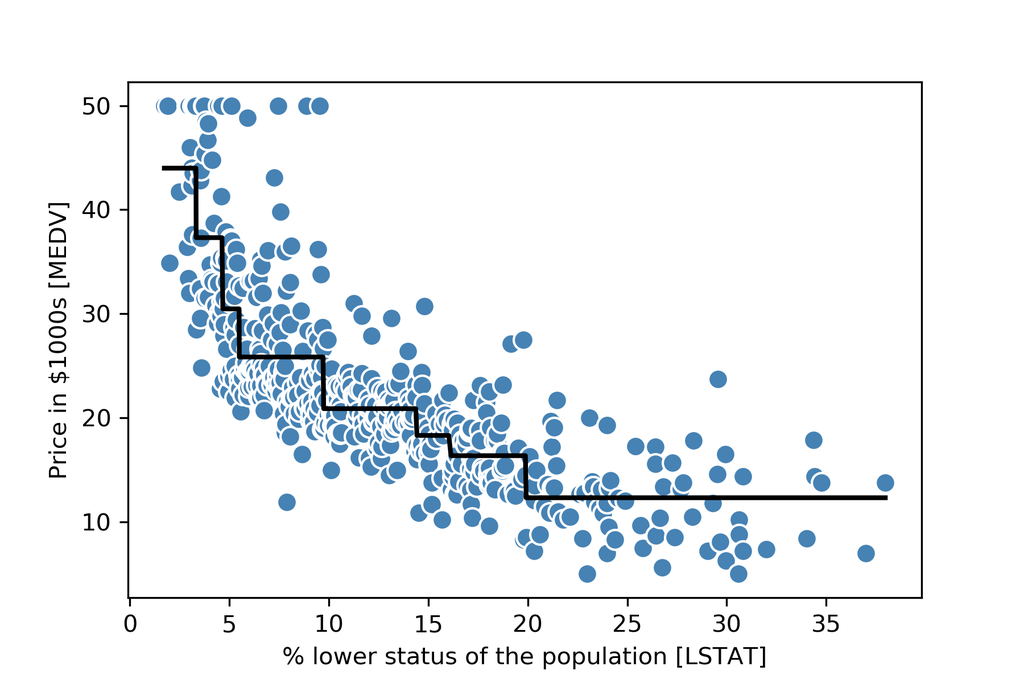

### Optimierung

**Optimierung**

Behandlung von Ausreißern ist schwer.

#### RANSAC

**RAN**dom **SA**mple **C**onsensous

1. Auswahl zufälliger Stichproben (*Inliners*) + Berechnung der Gewichte
2. Hinzufügen restlicher Datenpunkte und Berechnung von Abweichungen
   - Falls Abweichung klein ist, wird sie den Datenpunkten (*Inliners*) hinzugefügt
3. Neuberechnung der Gewichte
4. Abschätzen der Fehler und Überprüfung mit Schwellenwert

Parameter

- Anzahl der Stichprobe
- Anzahl der Versuche
- Schwellenwert
- Art der Abstandsbestimmung

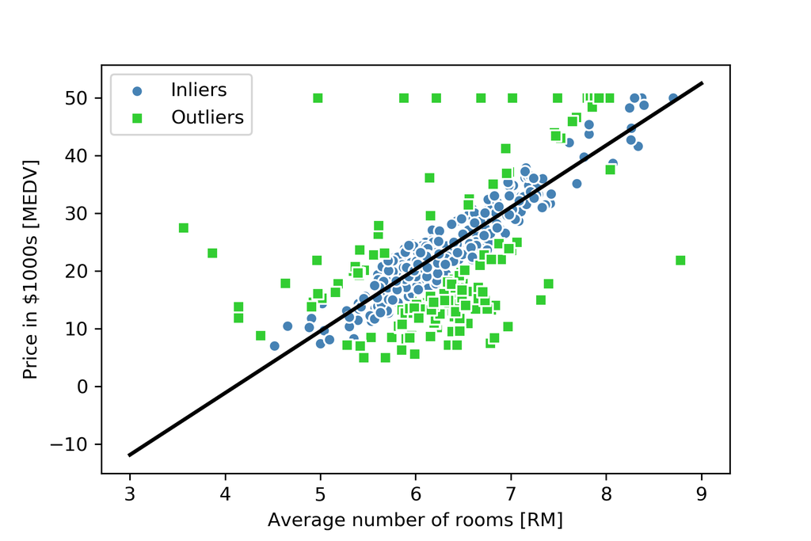

#### Regularisierung

**Regularisierung**

- Ähnlich zur Regularisierung bei Klassifizierern durch Hinzufügen von Informationen
- Ridge-Verfahren L2
- LASSO L1 (*Least Absolute Shrinkage and Selection Operator*)
- ElasticNet (Kompromiss zwischen Ridge und LASSO)

### Bewertung

**Bewertung** von Regressionsmodellen

#### Residuen-Diagramme

**Residuen-Diagramme**

Visualisierung der Abweichungen von Residuen bezüglich der tatsächlichen und der vorhergesagten Werte. Die Abweichungen sollten nahe 0 bzw. gleichverteilt um 0 sein. Falls Muster zu erkennen sind, ist das Modell vermutlich nicht in der Lage eine Vorhersage zu treffen.

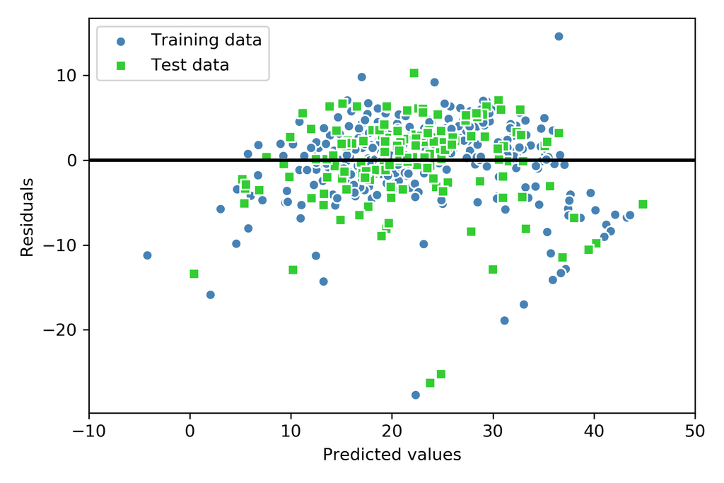

#### MSE

**Mean-Squared Error**

Fehler der Durchschnittswerte für Trainings- und Testdaten mittels

$$MSE = \frac{1}{n} \sum_{i=1}^{n} ( y^{(i)} - \hat{y}^{(i)} )^2.$$
Falls die Abweichung zwischen Trainings- und Testdaten zu groß ist, ist das Modell vermutlich überangepasst

#### Bestimmtheitsmaß $R^2$

**Bestimmtheitsmaß $R^2$**

Standardisierter MSE. Nutzt *Sum of squared Error (SSE)* und *Sum of squared Total (SST)*.

$$R^2 =1 - \frac{SSE}{SST} = 1 - \frac{MSE}{Var(y)}$$

## Ensemble Learning

Kombination von Klassifizieren, um einen Meta-Klassifizierer zu erhalten. Kooperation statt Konkurrenz. Es sollte abgewogen werden, ob sich der Rechenaufwand lohnt.

### Mehrheitsenscheidung

**Mehrheitsentscheidung**

Auswahl der Klasse, die von den meisten Klassifizieren vorhergesagt wurde.

- Berechnung mithilfe eines Modalwerts, der das am häufigsten vorkommende Element auswählt.
- Eine Gewichtung der Algorithmen ist möglich
- Statt binärer Entscheidung der Klassifizieren sind auch Wahrscheinlichkeiten denkbar
- Eine Überprüfung mit ROC-Kurven ist sinnvoll

### Bagging

**Bagging - Ensembles mit Bootstrap-Stichproben**

Nicht mehr das Trainieren verschiedener Klassifizierer mit den gleichen Daten, sondern diese in Untermengen aufteilen und an die Klassifizierer verteilen. Anschließend erneute Kombination durch Mehrheitsentscheidung.

- Ein Objekt kann auch mehrfach oder gar nicht in Untermengen enthalten sein
- Verfahren um Varianz zu verringern (nur bei Modellen mit geringem Bias sinnvoll)

### AdaBoost

**Adaptives Boosting**

Verfahren, um mit schwachen Klassifizierern eine bessere Korrektklassifizierungsrate zu erhalten, indem iterativ aus Fehlklassifizierungen gelernt werden soll.

- Schrittweises Trainieren der Klassifizieren
  - in jedem Schritt wird ein Teil der zuvor fehlklassifizierten Objekte hinzugefügt (stärker gewichtet)
- zuletzt eine Mehrheitsentscheidung der trainierten Klassifizierern
- Bias und Varianz können kleiner werden, neigt jedoch zu Überanpassung mit hoher Varianz

## Clusteranalyse

Verfahren des unüberwachten Lernens (nicht gekennzeichnete Daten) zum Finden von Kategorien / verborgenen Strukturen.

- anfällig für *Fluch der Dimensionalität* (Dimensionsreduktion ist wichtig)

### k-Means

**k-Means** zur Gruppierung von ähnlichen Objekten

- partionierendes prototypenbasiertes Verfahren
  - Zentroid (Durchschnitt ähnlicher Punkte mit stetigem Merkmal)
  - Medoid (repräsentativsten / am häufigsten vorkommender Punkt)
- gut für ringförmige Cluster und höherdimensionaler Daten
- Anzahl $k$ der Cluster muss im Vorhinein festgelegt werden
- harte Zuordnung (jedes Objekt wird genau einem Cluster zugeordnet)

#### Mathematische Grundlagen

Ähnlichkeit von Objekten wird durch die Distanz $d$ der quadrierten euklidischen Distanz zweier Punkte $x$ und $y$ festgelegt.

$$d(\mathbf{x}, \mathbf{y})^2 = \sum_{j=1}^m (x_j - y_j)^2 = \vert\vert \mathbf{x} - \mathbf{x} \vert\vert_2^2$$
- mit $j$ = Dimension der Merkmale

Sonstiges

- Minimierung von $d$ mittels des $SSE$ (auch Trägheit)
- Standardisierung sollte vorgenommen werden

Eine Verbesserung ist durch den **k-Means-++** Algorithmus gegeben, indem die anfänglichen Zentroiden nicht zufällig, sondern weit voneinander entfernt gesetzt werden.

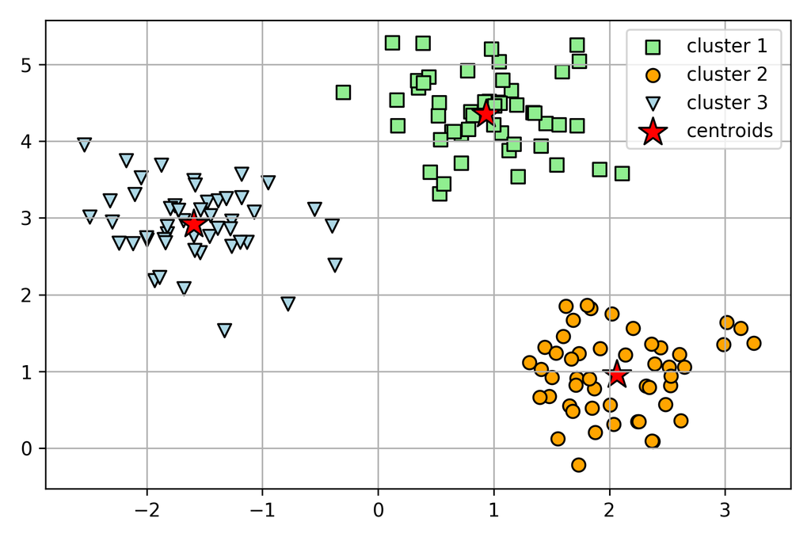

### FCM

**Fuzzy-C-Mean**-Algorithmus

- weiche Zuordnung (ersetzten der harten Clusterzugehörigkeit durch eine Wahrscheinlichkeit)
- Anzahl $k$ der Cluster muss auch im Vorhinein festgelegt werden

#### Mathematische Grundlagen

Minimierung der Zielfunktion $J_m$

$$J_m = \sum_{i=1}^n \sum_{j=1}^k \left(w^{(i,j)}\right)^m
{\vert\vert \mathbf{x}^{(i)} - \mathbf{\mu}^{(j)} \vert\vert}_2^2 ~ , ~~ m \in [1, \infty]$$
- mit $w^{(i,j)}$ als Wahrscheinlichkeit zwischen 0 und 1 - Exponent $m$ als *Fuzziness*-Koeffizient

### Bewertung

**Modellbewertung**

#### Ellbogenkriterium

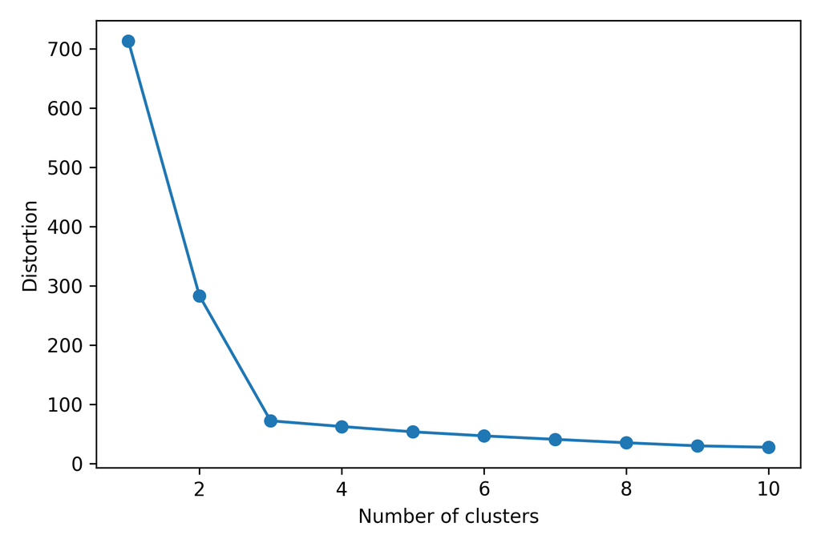

#### Silhouetten-Diagramm

**Silhouetten-Diagramm** als graphische Methode zur Darstellung der Qualität eines Clusters.

- Berechnung der Geschlossenheit $a$ (mittlere Distanz innerhalb eines Clusters)
- Berechnung der Distanz $b$ zum nächsten Cluster (mittlere Distanz zwischen Clustern)
- Berechnung der Silhouette

$$s^{(i)} = \frac{b^{(i)} - a^{(i)}}{\max(a^{(i)}, b^{(i)})}$$

##### Gut

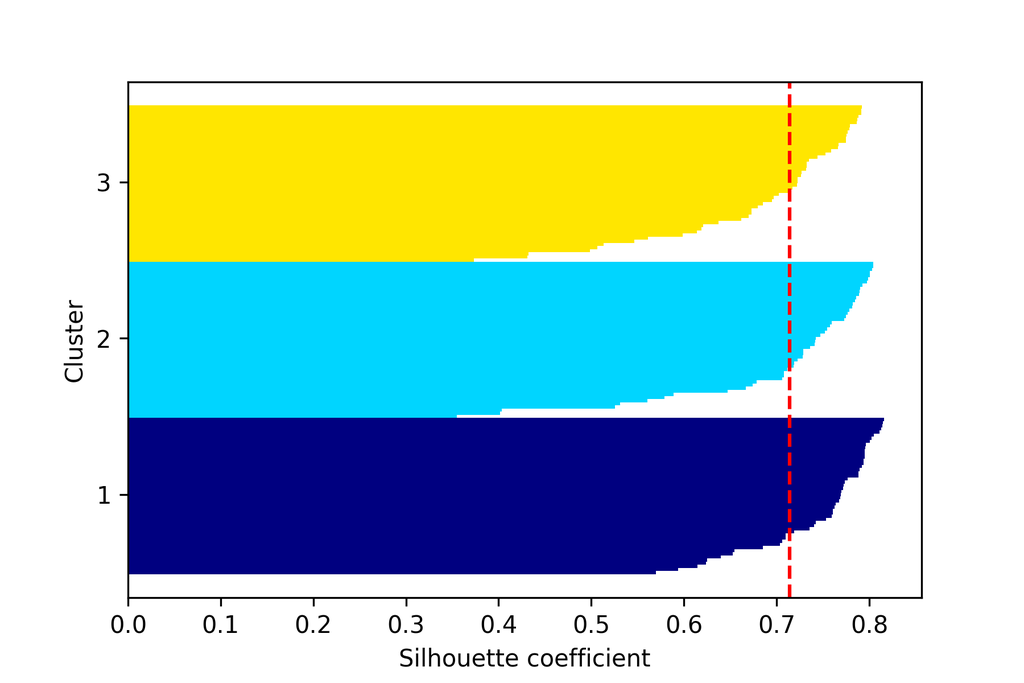

##### Schlecht

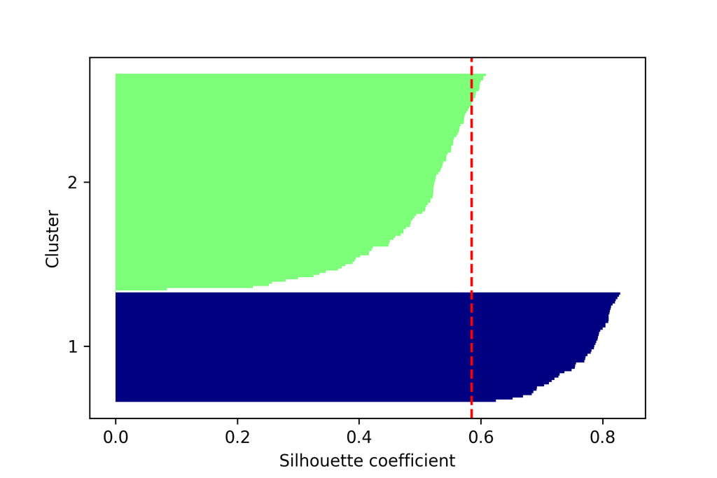

### Hierarchisch

**Hierarchisches Clustering**

- Anzahl $k$ der Cluster muss *nicht* bekannt sein

#### Divisiv

- Man geht von einem Cluster aus, das alle Objekte umfasst
- schrittweises Aufteilen in kleinere Cluster
- bis jedes Objekt ein Cluster bildet

#### Agglomerativ

- man geht davon aus, dass jedes Objekt ein Cluster bildet
- Zusammenführen der nächst-gelegenen Clusterpaare zu einem neuen Cluster
- bis nur noch ein Cluster verbleibt

Das Complete-Linkage Verfahren berechnet die Distanzmatrix aller Objekte, bevor die beiden nächstgelegenen Cluster zusammengeführt werden.

Dendogramm

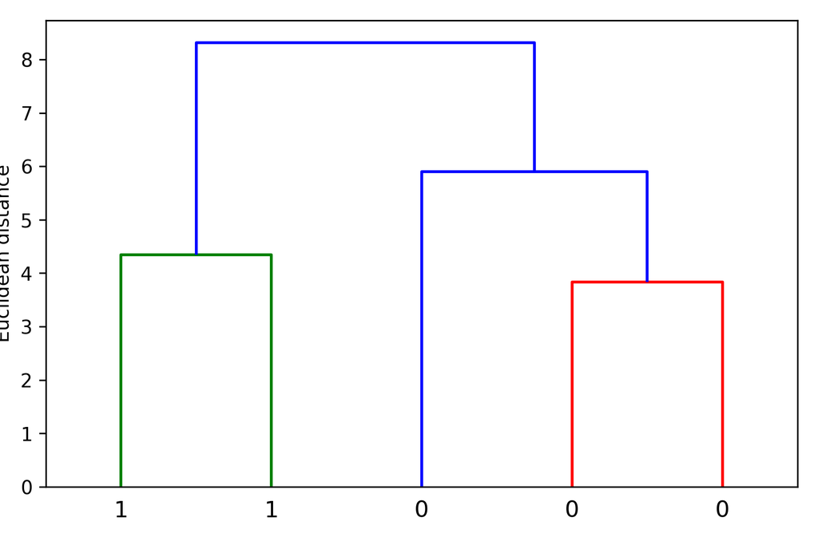

### DBSCAN

**D**ensity **B**ased **S**patial **C**lustering of **A**pplications with **N**oise

- keine Annahmen über ringförmige / sphärische Cluster notwendig
- nicht alle Objekte müssen Cluster zugehören (Rauschen)

#### Verfahren

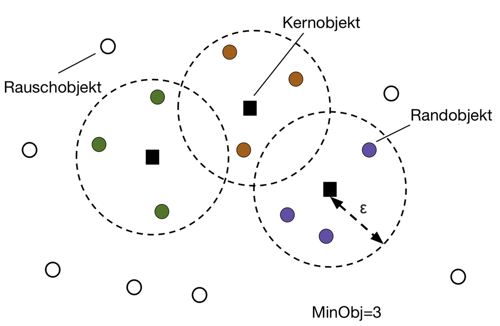

## Beispiel

### Natural Language Processing

**Natural Language Processing**

Klassifizierung

1. Durch reguläre Ausdrücke Sonderzeichen entfernen oder formatieren
2. Text in Token zerlegen (einzelne Wörter)
3. Tokens filtern
   - Auf Wortstamm bringen mittels *stemming*
   - Stoppwörter entfernen (durch `nltk` bereitgestellt)
4. Worte in Merkmale umwandeln (Merkmalsvektor, **Bag-of-Word**)
5. mittles tf-idf-Maß (**Raw Term Frequency**) durchweg häufig vokommende Wörter bestrafen
6. Rastersuche (oder stochastisches Verfahren), um das Modell zu trainieren
   - stochastisches Verfahren: Klassifizierer serialisieren

Topic Modeling (Clustering, unüberwacht)

Mittels Latent Dirichlet Allokation (LDA) Wortgruppen verschiedener Dokumente finden, die Themen widerspiegeln. Die Anzahl der Themen muss im Vorhinein festgelegt werden.

### Webanwendung

**Einbettung in eine Webanwendung**